# Taller III. Gestión Presupuestaria

Sebastian Freille

Universidad Nacional de Córdoba

# **Ejecución presupuestaria**

## Registración de ingresos y gastos

- A lo largo de todo el proceso presupuestario, los recursos y los gastos se van asignando y contabilizando en diferentes momentos.
- Los **momentos contables** son las etapas secuenciales relacionadas con la previsión y la ejecución de los gastos e ingresos.

## Registración de ingresos y gastos (cont.)

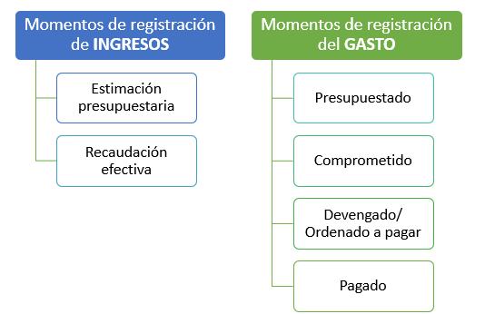

## Criterios de registración de ingresos

- Los ingresos públicos se registran en dos momentos:
  - **Presupuestado:** lo que se estima recaudar, según la Ley de Presupuesto.
  - **Recaudación:** cuando los fondos efectivamente ingresan a la Administración Pública.
- **Ejemplo - Momento de registración de un IMPUESTO**
  - **Presupuestado:** el gobierno, en función del nivel de actividad económica e inflación que espera para el año siguiente, presupuesta el monto que estima recaudar de impuestos.
  - **Recaudación:** cuando el contribuyente paga el monto correspondiente al impuesto y el dinero efectivamente ingresa en la cuenta del gobierno.

## Criterios de registración del gasto

- Los gastos públicos se registran en cuatro momentos:
  - **Presupuesto:** lo que se proyecta gastar, según la Ley de Presupuesto.
  - **Compromiso:** relación jurídica que dará lugar a una eventual salida de fondos. De carácter preventivo (está sujeta a la efectiva contraprestación).
  - **Devengamiento:** cuando por una relación jurídica se establece una obligación de la Administración.
  - **Pago:** Cuando los fondos efectivamente salen de la oficina de la Administración.

## Criterios de registración del gasto (cont.)

- **EJEMPLO. Momentos de registración de la compra de una computadora**
  - Al confeccionar el presupuesto para el año 2023, se prevé la compra de una computadora, por la que estima gastar $ 150.000.
    - **PRESUPUESTO 2023:** $ 150.000
  - A fines de mayo, se requiere la computadora, por lo que emite una orden de compra, solicitando así que se lleve adelante dicha adquisición.
    - **COMPROMETIDO Mayo 2023:** $150.000

## Criterios de registración del gasto (cont.)

- **EJEMPLO. Momentos de registración de la compra de una computadora**
  - A los 15 días, llega a la oficina la computadora. Desde este momento, el fisco tiene la obligación de abonar por dicho bien. Emite una orden de pago por el monto adeudado.
    - **DEVENGADO Junio 2023:** $150.000
  - A la semana, se transfiere desde la cuenta del gobierno a la cuenta del proveedor el dinero adeudado.
    - **PAGADO Junio 2023:** $150.000

## Deuda flotante (cont.)

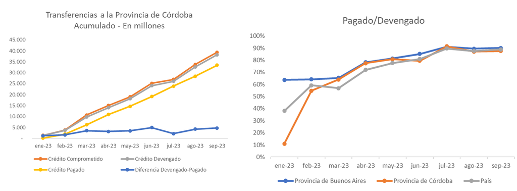

Deuda flotante: devengado menos pagado

## Deuda flotante (cont.)

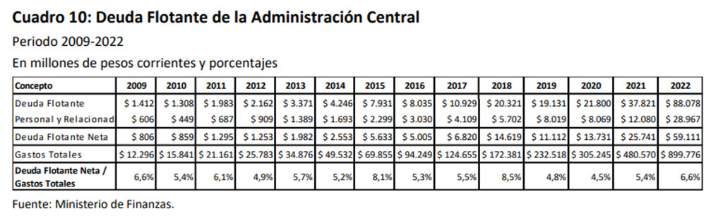

Evolución deuda flotante

# **Resultado y deuda**

## Resultado y deuda

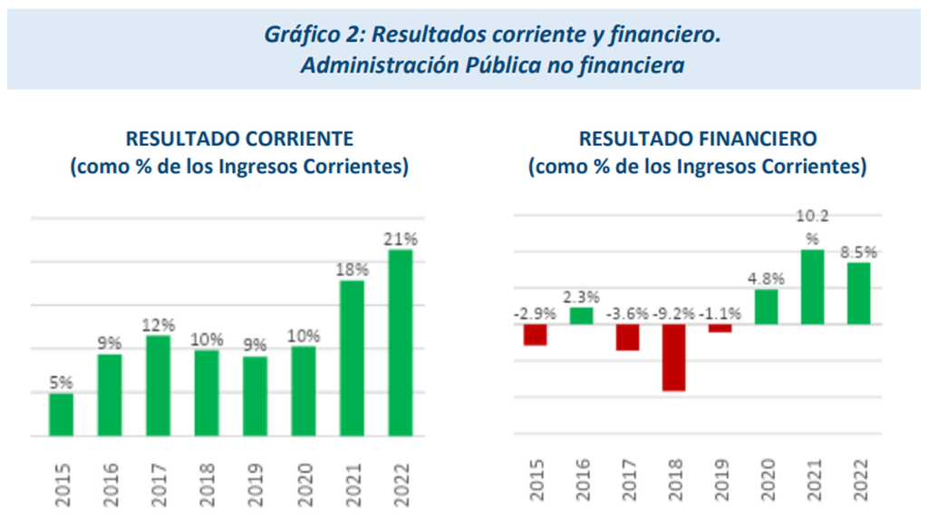

Resultados corriente y financiero

## Resultado y deuda (cont.)

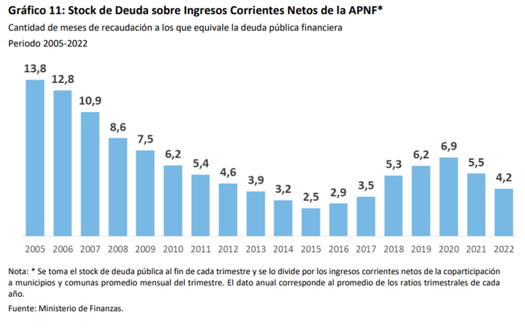

# **Transferencias a municipios**

## Transferencias a municipios

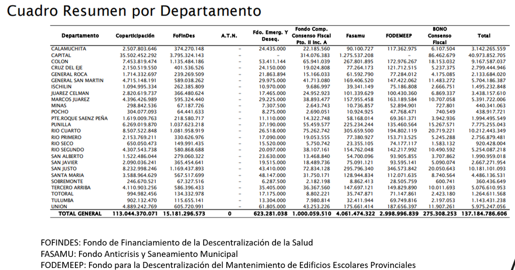

Mirando descentralización provincia-municipios (inter-departamento)

## Transferencias a municipios (cont.)

- Principales fondos de transferencias a municipios:
  - **FOFINDES:** Fondo de Financiamiento de la Descentralización de la Salud
  - **FASAMU:** Fondo Anticrisis y Saneamiento Municipal
  - **FODEMEEP:** Fondo para la Descentralización del Mantenimiento de Edificios Escolares Provinciales
- Existen otros fondos, algunos van desapareciendo y otros nuevos se van creando

## Transferencias a municipios (cont.)

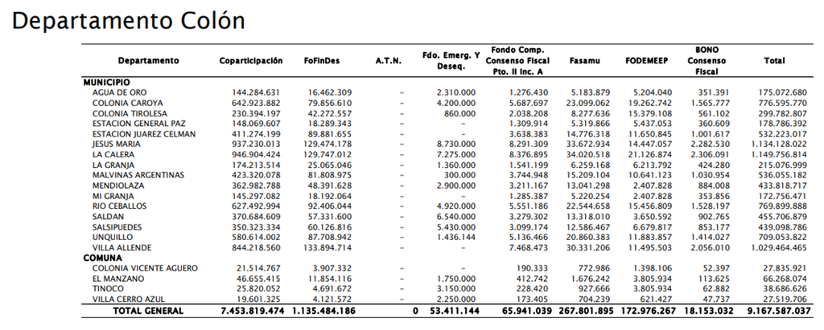

Mirando todos los gobiernos locales (intra-departamento)

# **Análisis avanzado de información presupuestaria**

## Reglas fiscales: ¿Qué es una Regla Fiscal?

- Es una **restricción permanente para la política fiscal**, la cual se refleja en un indicador de desempeño fiscal.
- El objetivo de la Regla Fiscal es alcanzar una **solidez económica** a lo largo del tiempo, promoviendo la disciplina fiscal evitando así la incertidumbre que genera la intervención discrecional.

## Tipos de reglas fiscales

- Existen dos criterios para clasificar las Reglas Fiscales:
  - **Por Límite:**
    - **Numéricas:** limitan o restringen un indicador fiscal.
    - **Procedimiento:** consisten en las pautas con las que se rigen los diversos agentes económicos dentro del contexto presupuestario.
    - **Transparencia:** consisten en las buenas prácticas implementadas para que exista un buen gobierno y transparencia fiscal.
  - **Por Indicador Fiscal**
    - deuda; equilibrio presupuestario; equilibrio presupuestario estructural; etc

## Reglas fiscales: ventajes

- **Disciplina Fiscal** para reducir el sesgo hacia el Déficit Fiscal
- Aumenta nivel de **credibilidad**
- Agentes económicos están **más y mejor informados**
- **Consistencia en el tiempo**

## Reglas fiscales: desventajas

- La credibilidad de las políticas públicas se ven afectadas en el caso que no exista un compromiso político para aplicar una política disciplinada o no cumpla los requisitos necesarios para que ésta sea sostenible
- Las reglas numéricas especialmente las que limitan el déficit y la deuda pueden **dificultar el desarrollo de políticas contra-cíclicas**
- Las reglas fiscales pueden estimular a la contabilidad “creativa”, para cumplir con la regla y restar transparencia a la política fiscal

## Reglas fiscales: diseño y características

- **Diseño:**
  - Un vínculo certero y estable entre el objetivo numérico y el objetivo final
  - Suficiente flexibilidad para responder a los shocks. Es necesario hacer la distinción entre choques temporales y permanentes
  - Un mecanismo institucional claro para mapear las desviaciones de los objetivos numéricos para ejercer medidas correctivas

## Reglas fiscales: diseño y características (cont.)

- **Características:**
  - **Transparencia:** debe ser de fácil entendimiento
  - **Consistencia:** debe estar acorde con el tamaño óptimo del estado
  - **Credibilidad:** Compromiso político para elevar el grado de confianza en los agentes económicos
  - **Obligatoriedad:** un incumplimiento de la regla lleva a la aplicación de sanciones

## Reglas fiscales: la experiencia argentina

> *¿PARA QUÉ SIRVEN LAS REGLAS FISCALES? UN ANÁLISIS CRÍTICO DE LA EXPERIENCIA ARGENTINA.* Miguel Braun y Nicolás Gadano. Agosto 2006

“En países con baja reputación fiscal e institucionalidad débil, las reglas pueden no solamente ser completamente inefectivas en materia fiscal, sino que su incumplimiento puede justamente contribuir a deteriorar más el frágil contexto institucional que dificulta su efectividad.”

[Documento completo](https://www.cippec.org/wp-content/uploads/2017/03/2299.pdf)

# **Responsabilidad fiscal en Córdoba y provincias**

## Responsabilidad fiscal en Córdoba

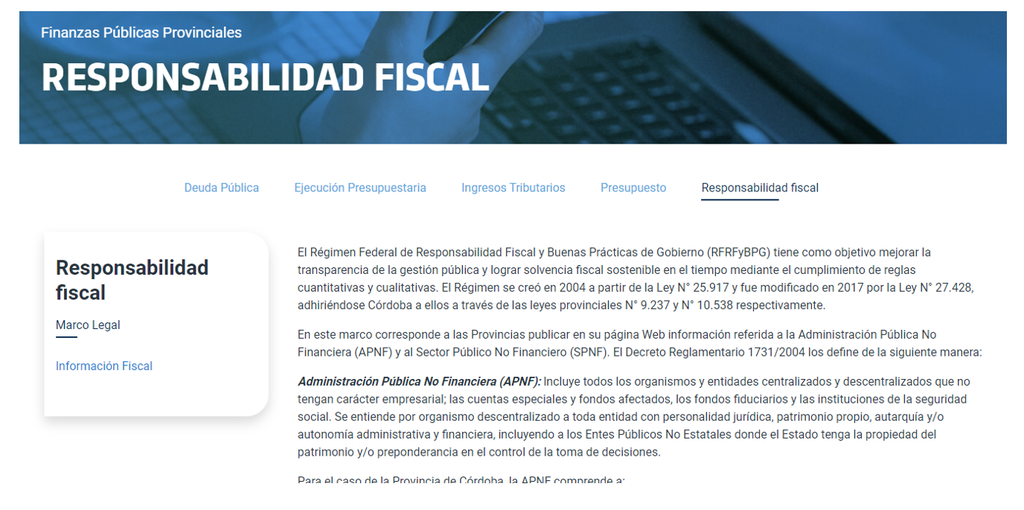

Marco normativo - Responsabilidad fiscal en Córdoba

## Responsabilidad fiscal en Córdoba (cont.)

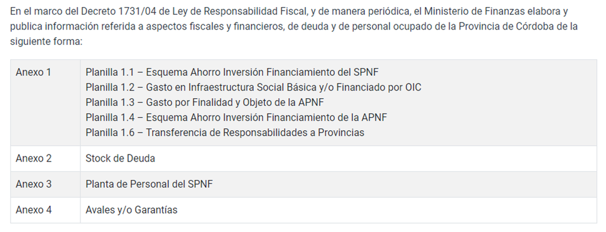

Marco normativo - Responsabilidad fiscal en Córdoba

## Responsabilidad fiscal: provincias

[figure not shown]

Monitoreo de cumplimiento fiscal

## Responsabilidad fiscal: provincias (cont.)

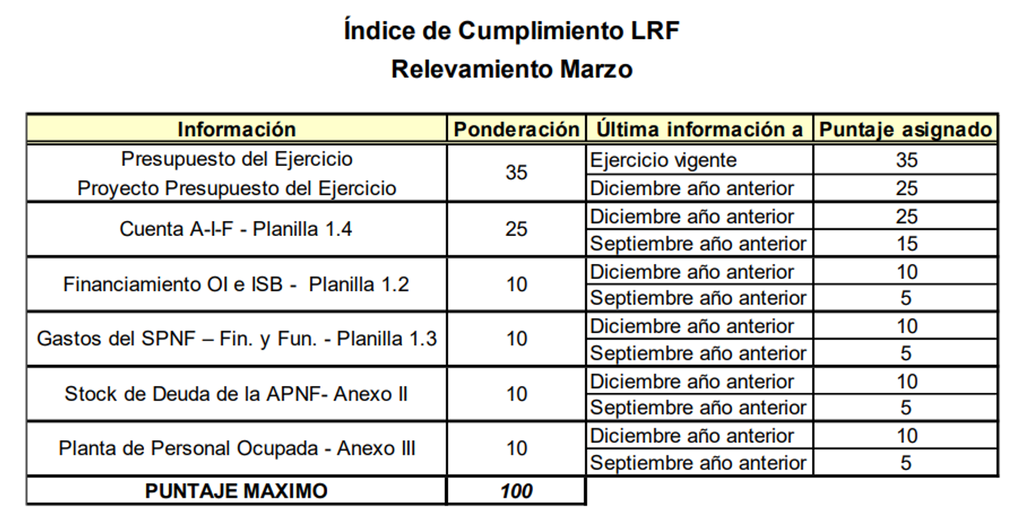

Criterios para indice

## Responsabilidad fiscal: provincias (cont.)

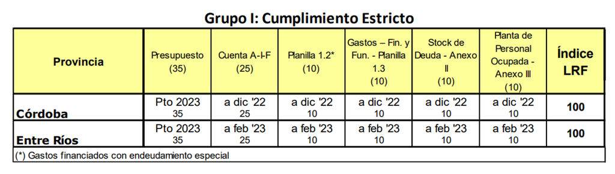

Comparación entre provincias

## Responsabilidad fiscal: provincias (cont.)

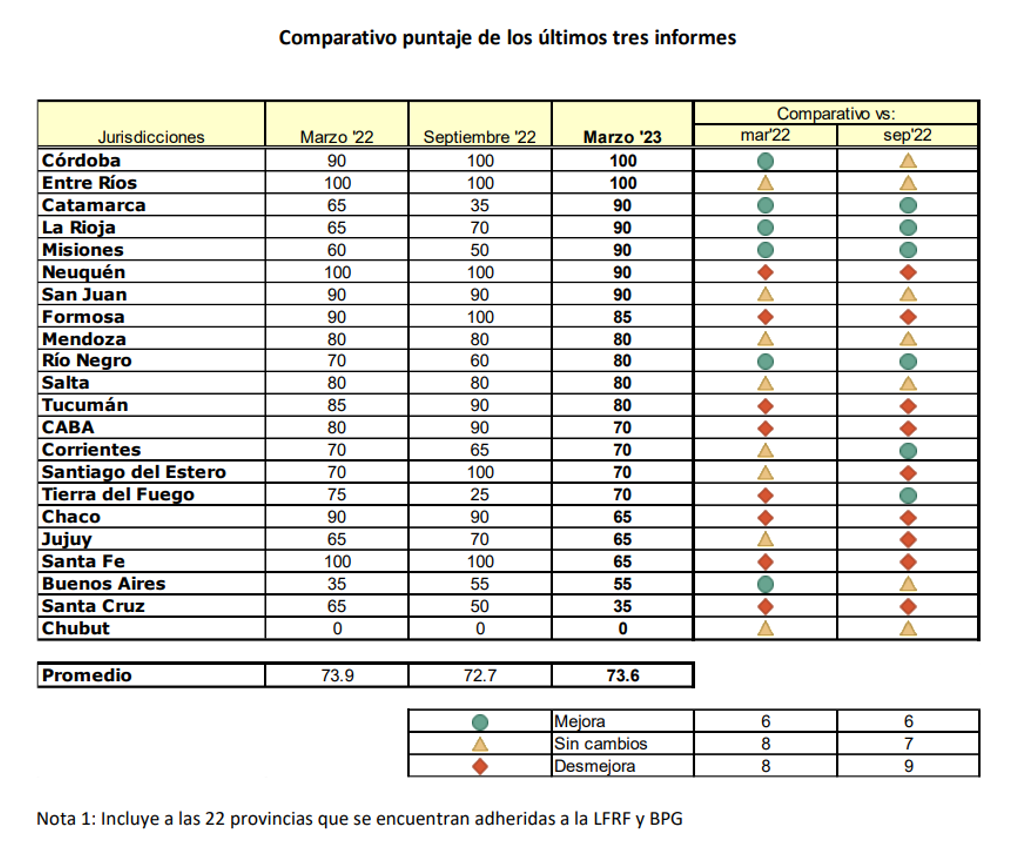

Comparación entre provincias: semáforo

# **Información fiscal en municipios de Córdoba**

## Información fiscal en municipios de Córdoba

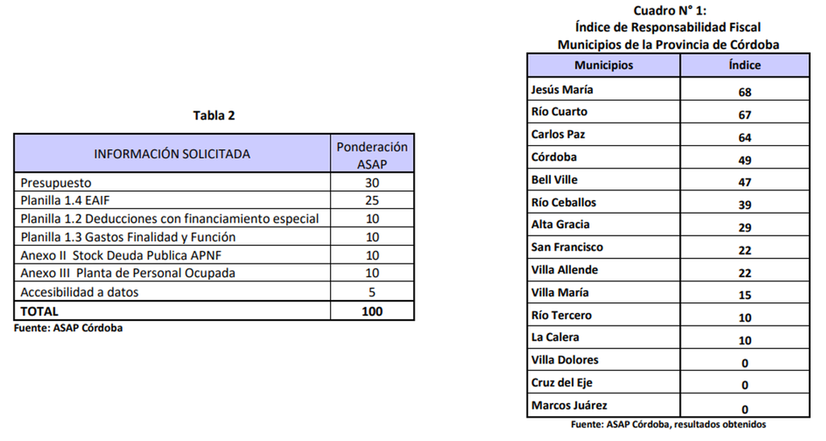

Responsabilidad fiscal en municipios

## Información fiscal en municipios de Córdoba (cont.)

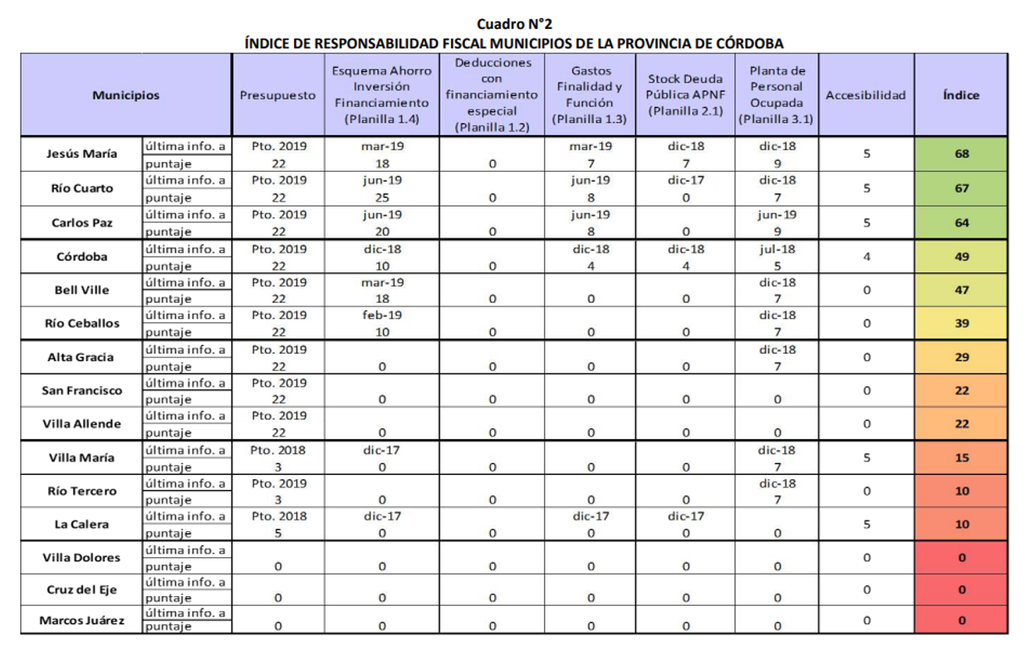

Responsabilidad fiscal en municipios

## Información fiscal en municipios de Córdoba (cont.)

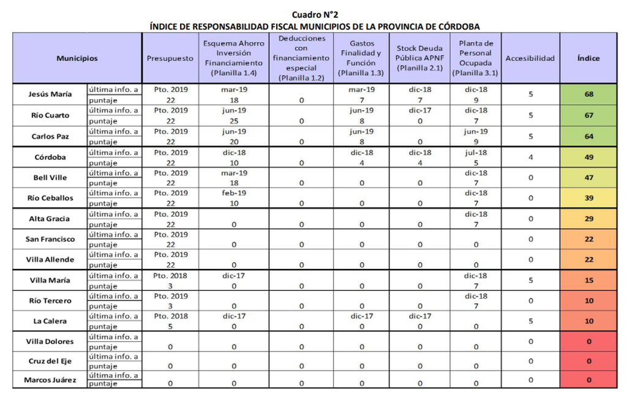

## Información fiscal en municipios de Córdoba (cont.)

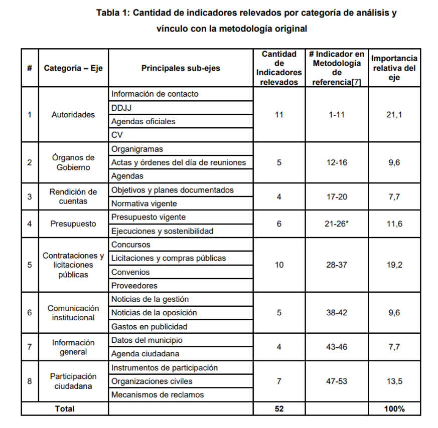

Transparencia en municipios

## Información fiscal en municipios de Córdoba (cont.)

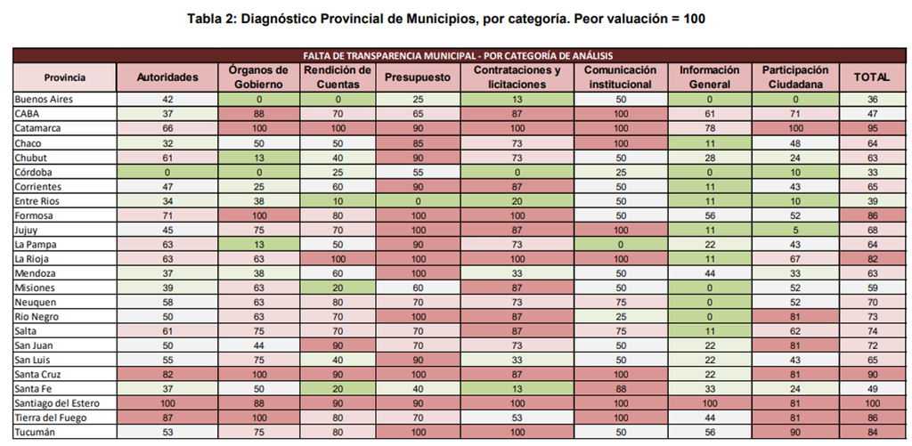

Transparencia en municipios

## Información fiscal en municipios de Córdoba (cont.)

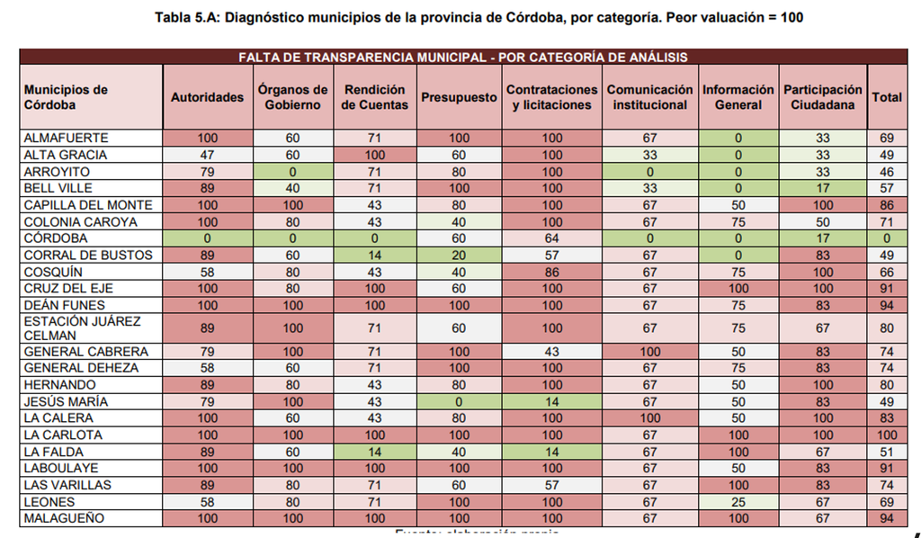

Transparencia en municipios

## Información fiscal en municipios de Córdoba (cont.)

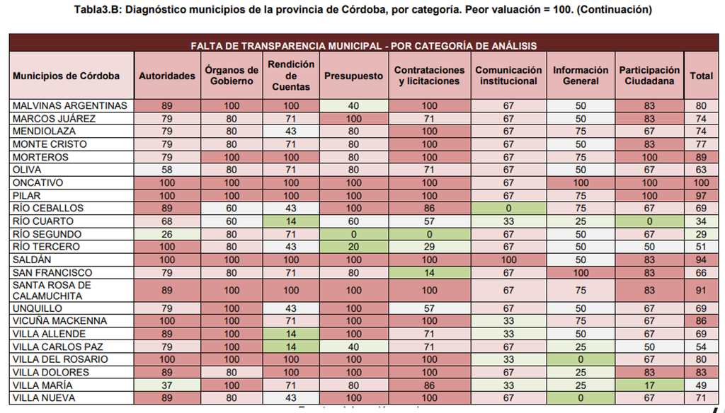

Transparencia en municipios